# Homework 03

Avery Shepherd

4/19/2021

```r
library(tidyverse)
library(infer)
library(simpleboot)
library(boot)
```

```r
f <- "https://raw.githubusercontent.com/difiore/ada-2021-datasets/main/KamilarAndCooperData.csv"
d <- read_csv(f, col_names = T)
glimpse(d)
```

```
## Rows: 213
## Columns: 44
## $ Scientific_Name         <chr> "Allenopithecus_nigroviridis", "Allocebus_tri…
## $ Family                  <chr> "Cercopithecidae", "Cercopithecidae", "Atelid…
## $ Genus                   <chr> "Allenopithecus", "Allocebus", "Alouatta", "A…
## $ Species                 <chr> "nigroviridis", "trichotis", "belzebul", "car…
## $ Brain_Size_Species_Mean <dbl> 58.02, NA, 52.84, 52.63, 51.70, 49.88, 51.13,…
## $ Brain_Size_Female_Mean  <dbl> 53.70, NA, 51.19, 47.80, 49.08, 48.04, 48.75,…
## $ Brain_size_Ref          <chr> "Isler et al 2008", NA, "Isler et al 2008", "…
## $ Body_mass_male_mean     <dbl> 6130.0, 92.0, 7270.0, 6525.0, 5800.0, 7150.0,…
## $ Body_mass_female_mean   <dbl> 3180.0, 84.0, 5520.0, 4240.0, 4550.0, 5350.0,…
## $ Mass_Dimorphism         <dbl> 1.928, 1.095, 1.317, 1.539, 1.275, 1.336, 1.7…
## $ Mass_Ref                <chr> "Isler et al 2008", "Smith and Jungers 1997",…
## $ MeanGroupSize           <dbl> NA, 1.000, 7.000, 8.000, 6.530, 12.000, 6.600…
## $ AdultMales              <dbl> NA, 1.000, 1.000, 2.300, 1.370, 2.900, 1.925,…
```

[output cut: 31 more lines]

## Chalenge 1

### Linear model

Fit weaning age ~ brain size regression model and produce a scatterplot with the fitted line superimposed upon the data

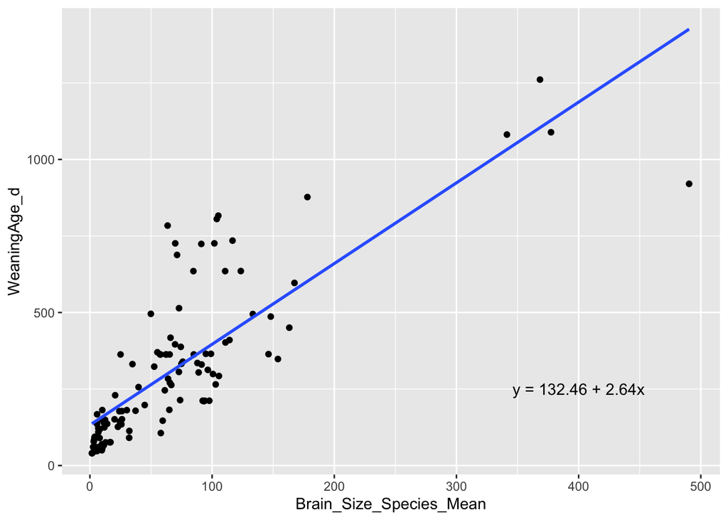

```r
lin_lm <- lm(data = d, WeaningAge_d ~ Brain_Size_Species_Mean)
lin_lm.intercept = coef(lin_lm)[[1]]
lin_lm.slope = coef(lin_lm)[[2]]
ggplot(d, aes(x = Brain_Size_Species_Mean, y = WeaningAge_d)) +
  geom_point() +
  geom_smooth(method = "lm", se = F) +
  annotate(geom = "text", x = 400, y = 250, label = paste0("y = ", round(lin_lm.intercept, 2), " + " , round(lin_lm.slope, 2), "x"))
```

```r
summary(lin_lm)
```

```
##
## Call:
## lm(formula = WeaningAge_d ~ Brain_Size_Species_Mean, data = d)
##
## Residuals:
##     Min      1Q  Median      3Q     Max
## -505.38  -90.61  -34.74   48.83  483.77
##
## Coefficients:
##                         Estimate Std. Error t value Pr(>|t|)
## (Intercept)             132.4640    19.1788   6.907 3.69e-10 ***
## Brain_Size_Species_Mean   2.6371     0.1847  14.276  < 2e-16 ***
## ---
## Signif. codes:  0 '***' 0.001 '**' 0.01 '*' 0.05 '.' 0.1 ' ' 1
##
## Residual standard error: 150.5 on 107 degrees of freedom
##   (104 observations deleted due to missingness)
## Multiple R-squared:  0.6557, Adjusted R-squared:  0.6525
## F-statistic: 203.8 on 1 and 107 DF,  p-value: < 2.2e-16
```

```r
ci <- confint(lin_lm, level = .9)
```

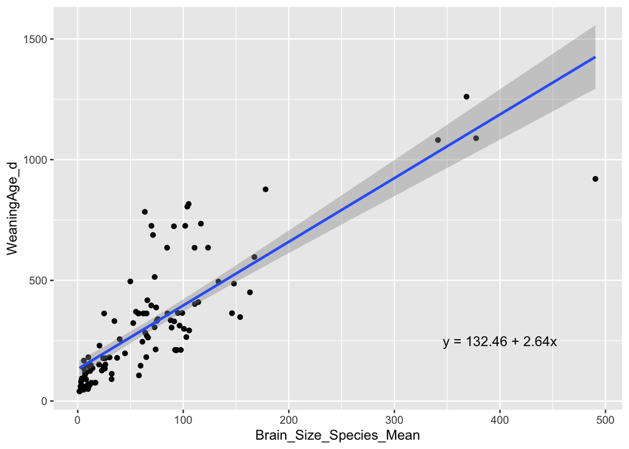

```r
ggplot(d, aes(x = Brain_Size_Species_Mean, y = WeaningAge_d)) +
  geom_point() +
  geom_smooth(method = "lm", level = .9) +
  annotate(geom = "text",
           x = 400, y = 250,
           label = paste0("y = ", round(lin_lm.intercept, 2), " + " , round(lin_lm.slope, 2), "x"))
```

Produce a point estimate and associated 90% prediction interval for the weaning age of a species whose brain weight is 750 gm. Do you trust the model to predict observations accurately for this value of the explanatory variable? Why or why not?

```r
predict(lin_lm, newdata = data.frame(Brain_Size_Species_Mean = 750),
        interval = "predict",
        level = .9)
```

```
##        fit      lwr      upr
## 1 2110.294 1783.832 2436.757
```

### Logged Model

Fit log(weaning age) ~ log(brain size) regression model and produce a scatterplot with the fitted line superimposed upon the data

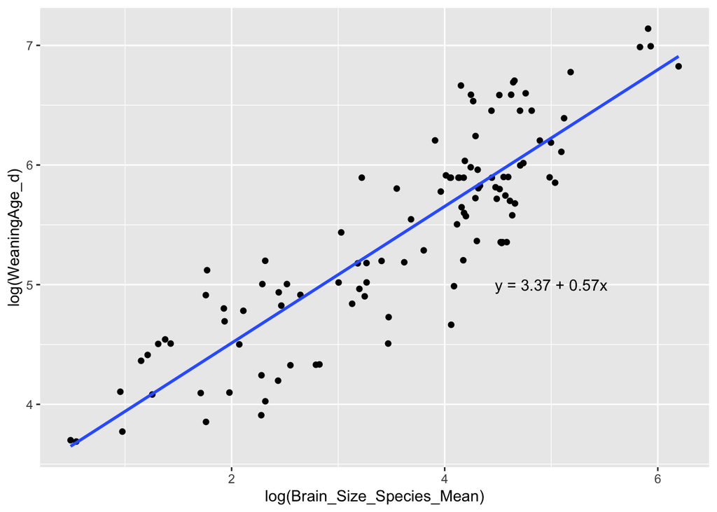

```r
log_lm <- lm(data = d, log(WeaningAge_d) ~ log(Brain_Size_Species_Mean))
log_lm.intercept = coef(log_lm)[[1]]
log_lm.slope = coef(log_lm)[[2]]
ggplot(d, aes(x = log(Brain_Size_Species_Mean), y = log(WeaningAge_d))) +
  geom_point() +
  geom_smooth(method = "lm", se = F) +
  annotate(geom = "text", x = 5, y = 5, label = paste0("y = ", round(log_lm.intercept, 2), " + " , round(log_lm.slope, 2), "x"))
```

```r
summary(log_lm)
```

```
##
## Call:
## lm(formula = log(WeaningAge_d) ~ log(Brain_Size_Species_Mean),
##     data = d)
##
## Residuals:
##     Min      1Q  Median      3Q     Max
## -1.0244 -0.2523 -0.0131  0.3225  0.9228
##
## Coefficients:
##                              Estimate Std. Error t value Pr(>|t|)
## (Intercept)                   3.36985    0.11671   28.88   <2e-16 ***
## log(Brain_Size_Species_Mean)  0.57116    0.03061   18.66   <2e-16 ***
## ---
## Signif. codes:  0 '***' 0.001 '**' 0.01 '*' 0.05 '.' 0.1 ' ' 1
##
## Residual standard error: 0.4108 on 107 degrees of freedom
##   (104 observations deleted due to missingness)
## Multiple R-squared:  0.765,  Adjusted R-squared:  0.7628
## F-statistic: 348.3 on 1 and 107 DF,  p-value: < 2.2e-16
```

```r
ci <- confint(log_lm, level = .9)
```

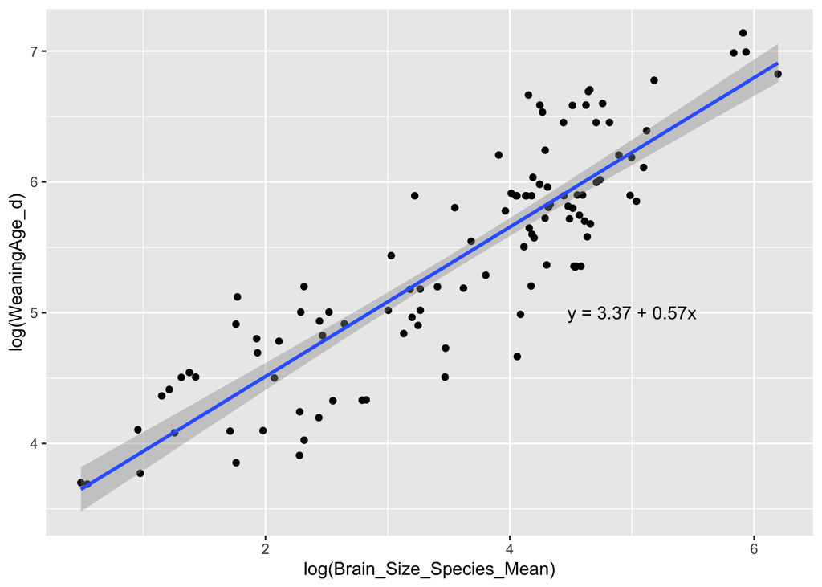

```r
ggplot(d, aes(x = log(Brain_Size_Species_Mean), y = log(WeaningAge_d))) +
  geom_point() +
  geom_smooth(method = "lm", level = .9) +
  annotate(geom = "text",
           x = 5, y = 5,
           label = paste0("y = ", round(log_lm.intercept, 2), " + " , round(log_lm.slope, 2), "x"))
```

Produce a point estimate and associated 90% prediction interval for the weaning age of a species whose brain weight is 750 gm. Do you trust the model to predict observations accurately for this value of the explanatory variable? Why or why not?

```r
predict(lin_lm, newdata = data.frame(Brain_Size_Species_Mean = log(750)),
        interval = "predict",
        level = .9)
```

```
##        fit       lwr      upr
## 1 149.9219 -101.6784 401.5221
```

Looking at your two models (i.e., untransformed versus log-log transformed), which do you think is better? Why? *I think that the log transformed model is better because when the values are logged it becomes a much more linear relationship, meaning the slope is more accurate for the values.*

## Challenge 2

Using the “KamilarAndCooperData.csv” dataset, run a linear regression looking at log(MeanGroupSize) in relation to log(Body_mass_female_mean) and report your β coeffiecients (slope and intercept).

```r
d$logMeanGroupSize <- log(d$MeanGroupSize)
d$logBody_mass_female_mean <- log(d$Body_mass_female_mean)
c2lm <- lm(data = d, logMeanGroupSize ~ logBody_mass_female_mean)
summary(c2lm)
```

```
##
## Call:
## lm(formula = logMeanGroupSize ~ logBody_mass_female_mean, data = d)
##
## Residuals:
##      Min       1Q   Median       3Q      Max
## -2.85428 -0.66210  0.03604  0.63941  2.51998
##
## Coefficients:
##                          Estimate Std. Error t value Pr(>|t|)
## (Intercept)              -1.77726    0.43752  -4.062 8.06e-05 ***
## logBody_mass_female_mean  0.50628    0.05563   9.102 8.08e-16 ***
## ---
## Signif. codes:  0 '***' 0.001 '**' 0.01 '*' 0.05 '.' 0.1 ' ' 1
##
## Residual standard error: 0.9373 on 140 degrees of freedom
##   (71 observations deleted due to missingness)
## Multiple R-squared:  0.3717, Adjusted R-squared:  0.3673
## F-statistic: 82.84 on 1 and 140 DF,  p-value: 8.078e-16
```

β0 is -1.7772580 and β1 is 0.5062813

Then, use bootstrapping to sample from the dataset 1000 times with replacement, each time fitting the same model and calculating the appropriate coefficients. This generates a bootstrap sampling distribution for each β coefficient. Plot a histogram of these sampling distributions for β0 and β1.

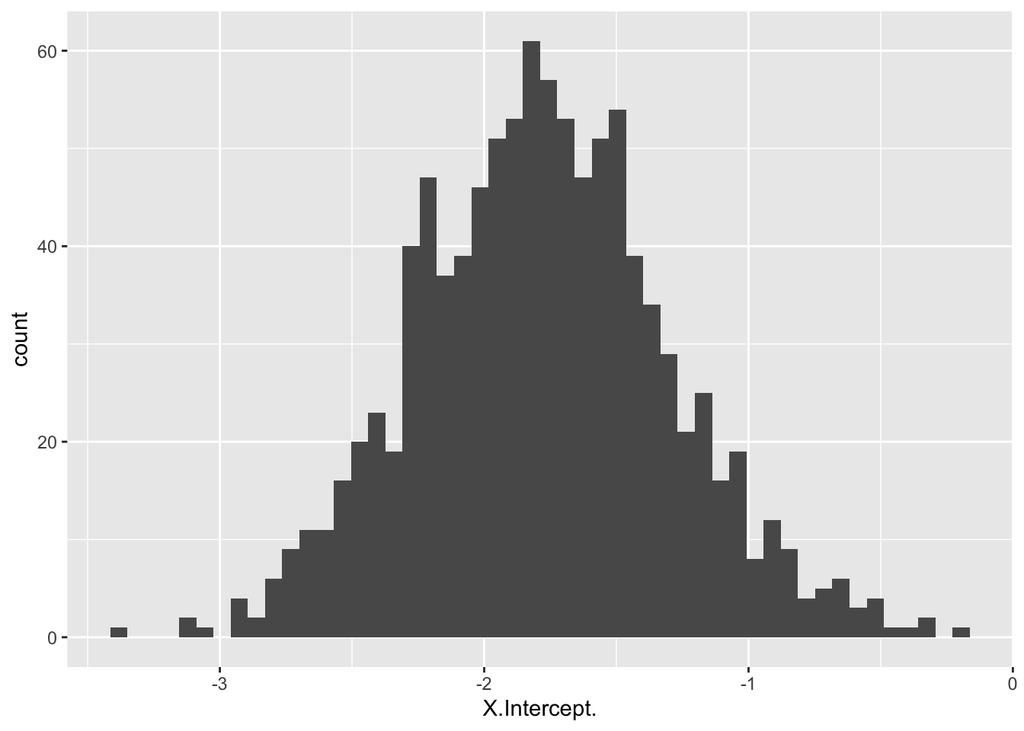

```r
boot_lm <- lm.boot(c2lm, 1000, rows = T)
boot_coefs <- data.frame(t(samples(boot_lm, "coef")))
ggplot(boot_coefs, aes(x = X.Intercept.)) + geom_histogram(bins = 50)
```

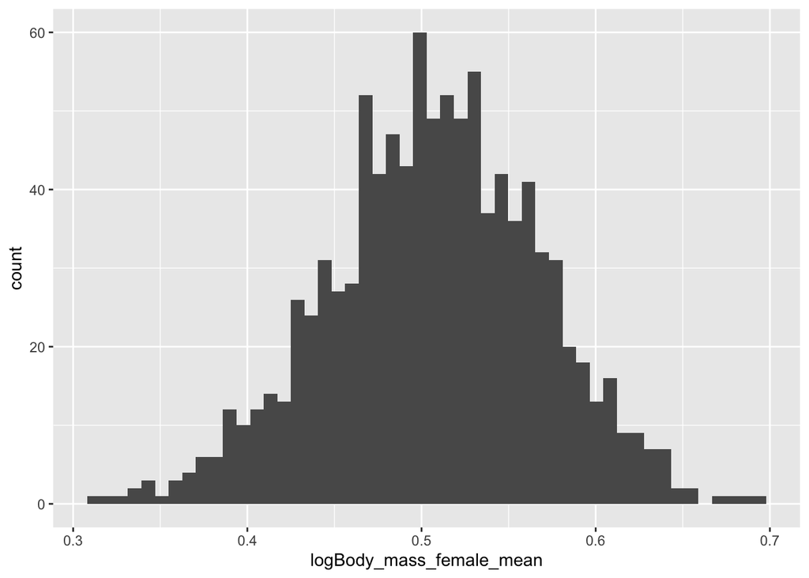

```r
ggplot(boot_coefs, aes(x = logBody_mass_female_mean)) + geom_histogram(bins = 50)
```

Estimate the standard error for each of your  
β coefficients as the standard deviation of the sampling distribution from your bootstrap.

```r
boot_coefs$SE <- (samples(boot_lm, "rss") / 211) / sqrt(samples(boot_lm, "rss"))
mean(boot_coefs$SE)
```

```
## [1] 0.05195918
```

Also determine the 95% CI for each of your β coefficients based on the appropriate quantiles from your sampling distribution

```r
boot_coefs$upperCI <- boot_coefs$SE + boot_coefs$logBody_mass_female_mean
boot_coefs$lowerCI <- boot_coefs$SE - boot_coefs$logBody_mass_female_mean
# upper
mean(boot_coefs$upperCI)
```

```
## [1] 0.5588837
```

```r
mean(boot_coefs$lowerCI)
```

```
## [1] -0.4549654
```

How do the SEs estimated from the bootstrap sampling distribution compare to those estimated mathematically as part of lm() function?

```r
coef(summary(c2lm))[, "Std. Error"]
```

```
##              (Intercept) logBody_mass_female_mean
##               0.43751572               0.05562507
```

How do your bootstrap CIs compare to those estimated mathematically as part of the lm() function?

```r
confint(c2lm, level = .95)
```

```
##                               2.5 %     97.5 %
## (Intercept)              -2.6422501 -0.9122659
## logBody_mass_female_mean  0.3963075  0.6162550
```

## Challenge 3

Write your own function, called boot_lm(), that takes as its arguments a dataframe (d=), a linear model (model=, written as a character string, e.g., “logGS ~ logBM”), a user-defined confidence interval level (conf.level=, with default “0.95”), and a number of bootstrap replicates (reps=, with default “1000”). Your function should return a dataframe that includes: the β coefficient names (β0, β1, etc.); the value of the β coefficients, their standard errors, and their upper and lower CI limits for the linear model based on your original dataset; and the mean β coefficient estimates, SEs, and CI limits for those coefficients based on your bootstrap.

```r
boot_lm <- function(d, model, conf.level=.95, reps=1000) {
  form = as.formula(model)
  results <- data.frame(beta0 = numeric(),
                        beta1 = numeric(),
                        beta0SE = numeric(),
                        beta1SE = numeric(),
                        beta0low = numeric(),
                        beta0upp = numeric(),
                        beta1low = numeric(),
                        beta1upp = numeric())
  for (i in  1:reps) {
    data <- d[sample(x = 1:length(d), size = length(d), replace = TRUE),]
    mod <- lm(form, data)
    coefs <- coef(summary(mod))
    confs <- confint(mod)
    res <- data.frame(beta0 = coefs[1, "Estimate"],
                      beta1 = coefs[2, "Estimate"],
                      beta0SE = coefs[1, "Std. Error"],
                      beta1SE = coefs[2, "Std. Error"],
                      beta0low = confs[1,1],
                      beta0upp = confs[1,2],
                      beta1low = confs[2,1],
                      beta1upp = confs[2,2])
    if (nrow(coefs) == 3) {
      res <- cbind(res, data.frame(beta2 = coefs[3, "Estimate"],
                      beta2SE = coefs[3, "Std. Error"],
                      beta2low = confs[3,1],
                      beta2upp = confs[3,2]))
    }
    results <- rbind(results, res)
  }

  results$meanbeta0 <- mean(results$beta0)
  results$meanbeta1 <- mean(results$beta1)
  results$meanbeta0SE <- mean(results$beta0SE)
  results$meanbeta1SE <- mean(results$beta1SE)
  results$meanbeta0low <- mean(results$beta0low)
  results$meanbeta0upp <- mean(results$beta0upp)
  results$meanbeta1low <- mean(results$beta1low)
  results$meanbeta1upp <- mean(results$beta1upp)
  if (nrow(coefs) == 3) {
    results$meanbeta2 <- mean(results$beta2)
    results$meanbeta2SE <- mean(results$beta2SE)
    results$meanbeta2low <- mean(results$beta2low)
    results$meanbeta2upp <- mean(results$beta2upp)
  }
  return(results)
}
```

Use your function to run the following models on the “KamilarAndCooperData.csv” dataset: log(MeanGroupSize) ~ log(Body_mass_female_mean)

```r
r <- boot_lm(d, "log(MeanGroupSize) ~ log(Body_mass_female_mean)")
glimpse(r)
```

```
## Rows: 1,000
## Columns: 16
## $ beta0        <dbl> -0.9042974, -2.4767283, -1.7060900, -1.8944490, -1.95360…
## $ beta1        <dbl> 0.3963395, 0.6304589, 0.4976473, 0.5441792, 0.5139754, 0…
## $ beta0SE      <dbl> 0.6628087, 0.8509737, 0.5272686, 0.5200100, 0.5203222, 0…
## $ beta1SE      <dbl> 0.09088085, 0.11579734, 0.07074898, 0.07127052, 0.069200…
## $ beta0low     <dbl> -2.269378, -4.217165, -2.777629, -2.950125, -3.011030, -…
## $ beta0upp     <dbl> 0.460782717, -0.736291715, -0.634551294, -0.838772554, -…
## $ beta1low     <dbl> 0.2091669, 0.3936267, 0.3538681, 0.3994923, 0.3733440, 0…
## $ beta1upp     <dbl> 0.5835122, 0.8672911, 0.6414265, 0.6888660, 0.6546069, 0…
## $ meanbeta0    <dbl> -1.596275, -1.596275, -1.596275, -1.596275, -1.596275, -…
## $ meanbeta1    <dbl> 0.484387, 0.484387, 0.484387, 0.484387, 0.484387, 0.4843…
## $ meanbeta0SE  <dbl> 0.7424601, 0.7424601, 0.7424601, 0.7424601, 0.7424601, 0…
## $ meanbeta1SE  <dbl> 0.09830957, 0.09830957, 0.09830957, 0.09830957, 0.098309…
## $ meanbeta0low <dbl> -3.116514, -3.116514, -3.116514, -3.116514, -3.116514, -…
## $ meanbeta0upp <dbl> -0.07603665, -0.07603665, -0.07603665, -0.07603665, -0.0…
## $ meanbeta1low <dbl> 0.2830912, 0.2830912, 0.2830912, 0.2830912, 0.2830912, 0…
## $ meanbeta1upp <dbl> 0.6856829, 0.6856829, 0.6856829, 0.6856829, 0.6856829, 0…
```

log(DayLength_km) ~ log(Body_mass_female_mean)

```r
r <- boot_lm(d, "log(DayLength_km) ~ log(Body_mass_female_mean)")
glimpse(r)
```

```
## Rows: 1,000
## Columns: 16
## $ beta0        <dbl> -3.024278028, -1.306953705, -0.807015189, -2.513577267, …
## $ beta1        <dbl> 0.41127246, 0.17431380, 0.09562296, 0.36727831, 0.167891…
## $ beta0SE      <dbl> 0.8537915, 1.0836400, 1.4238827, 0.7494175, 0.8852961, 1…
## $ beta1SE      <dbl> 0.10869094, 0.14690794, 0.17629574, 0.10032108, 0.117638…
## $ beta0low     <dbl> -4.834235, -3.567387, -3.798482, -4.063866, -3.229967, -…
## $ beta0upp     <dbl> -1.2143210, 0.9534797, 2.1844514, -0.9632890, 0.4420165,…
## $ beta1low     <dbl> 0.180857955, -0.132130783, -0.274760652, 0.159748346, -0…
## $ beta1upp     <dbl> 0.6416870, 0.4807584, 0.4660066, 0.5748083, 0.4118586, 0…
## $ meanbeta0    <dbl> -1.301277, -1.301277, -1.301277, -1.301277, -1.301277, -…
## $ meanbeta1    <dbl> 0.1780187, 0.1780187, 0.1780187, 0.1780187, 0.1780187, 0…
## $ meanbeta0SE  <dbl> 0.9289509, 0.9289509, 0.9289509, 0.9289509, 0.9289509, 0…
## $ meanbeta1SE  <dbl> 0.1219446, 0.1219446, 0.1219446, 0.1219446, 0.1219446, 0…
## $ meanbeta0low <dbl> -3.231835, -3.231835, -3.231835, -3.231835, -3.231835, -…
## $ meanbeta0upp <dbl> 0.6292821, 0.6292821, 0.6292821, 0.6292821, 0.6292821, 0…
## $ meanbeta1low <dbl> -0.07540613, -0.07540613, -0.07540613, -0.07540613, -0.0…
## $ meanbeta1upp <dbl> 0.4314435, 0.4314435, 0.4314435, 0.4314435, 0.4314435, 0…
```

log(DayLength_km) ~ log(Body_mass_female_mean) + log(MeanGroupSize)

```r
r <- boot_lm(d, "log(DayLength_km) ~ log(Body_mass_female_mean) + log(MeanGroupSize)")
glimpse(r)
```

```
## Rows: 1,000
## Columns: 24
## $ beta0        <dbl> -0.87910013, -1.71641221, -0.16070741, -1.23135420, -0.8…
## $ beta1        <dbl> -0.08598392, -0.01998212, -0.21293860, -0.05517331, -0.1…
## $ beta0SE      <dbl> 0.5829335, 0.6287163, 0.9252288, 0.5928914, 0.8824780, 0…
## $ beta1SE      <dbl> 0.08794201, 0.08931871, 0.15859415, 0.11365740, 0.162220…
## $ beta0low     <dbl> -2.08498987, -3.04288762, -2.10454104, -2.46433933, -2.6…
## $ beta0upp     <dbl> 0.326789598, -0.389936801, 1.783126209, 0.001630938, 1.0…
## $ beta1low     <dbl> -0.2679058, -0.2084281, -0.5461325, -0.2915368, -0.45929…
## $ beta1upp     <dbl> 0.095937978, 0.168463889, 0.120255354, 0.181190192, 0.22…
## $ beta2        <dbl> 0.7235282, 0.8172240, 0.8347293, 0.7837911, 0.7806776, 0…
## $ beta2SE      <dbl> 0.08973614, 0.15726735, 0.20366382, 0.18741811, 0.251924…
## $ beta2low     <dbl> 0.5378948, 0.4854189, 0.4068475, 0.3940338, 0.2466223, 0…
## $ beta2upp     <dbl> 0.9091615, 1.1490291, 1.2626111, 1.1735484, 1.3147328, 1…
## $ meanbeta0    <dbl> -0.4839335, -0.4839335, -0.4839335, -0.4839335, -0.48393…
## $ meanbeta1    <dbl> -0.168263, -0.168263, -0.168263, -0.168263, -0.168263, -…
## $ meanbeta0SE  <dbl> 0.7055126, 0.7055126, 0.7055126, 0.7055126, 0.7055126, 0…
## $ meanbeta1SE  <dbl> 0.1135668, 0.1135668, 0.1135668, 0.1135668, 0.1135668, 0…
## $ meanbeta0low <dbl> -1.966022, -1.966022, -1.966022, -1.966022, -1.966022, -…
## $ meanbeta0upp <dbl> 0.9981555, 0.9981555, 0.9981555, 0.9981555, 0.9981555, 0…
## $ meanbeta1low <dbl> -0.4068362, -0.4068362, -0.4068362, -0.4068362, -0.40683…
## $ meanbeta1upp <dbl> 0.07031015, 0.07031015, 0.07031015, 0.07031015, 0.070310…
## $ meanbeta2    <dbl> 0.7993662, 0.7993662, 0.7993662, 0.7993662, 0.7993662, 0…
## $ meanbeta2SE  <dbl> 0.1595838, 0.1595838, 0.1595838, 0.1595838, 0.1595838, 0…
## $ meanbeta2low <dbl> 0.4641377, 0.4641377, 0.4641377, 0.4641377, 0.4641377, 0…
## $ meanbeta2upp <dbl> 1.134595, 1.134595, 1.134595, 1.134595, 1.134595, 1.1345…
```

## EXTRA CREDIT:

Using a loop, run your function from Challenge 3 to generate mean β1 coefficents and lower and upper limits for the 95% CI for the log(MeanGroupSize) ~ log(Body_mass_female_mean) model with different numbers of bootstrap replicates from 10 to 200 by 5s and plot these using {ggplot2}. That is, plot these as three LINES, with the number of replicates as the x aesthetic and the mean, lower CI limit, and upper CI limit from each set of replicates as the y aesthetic. Also plot as a horizontal line the β1 value from the original linear model.

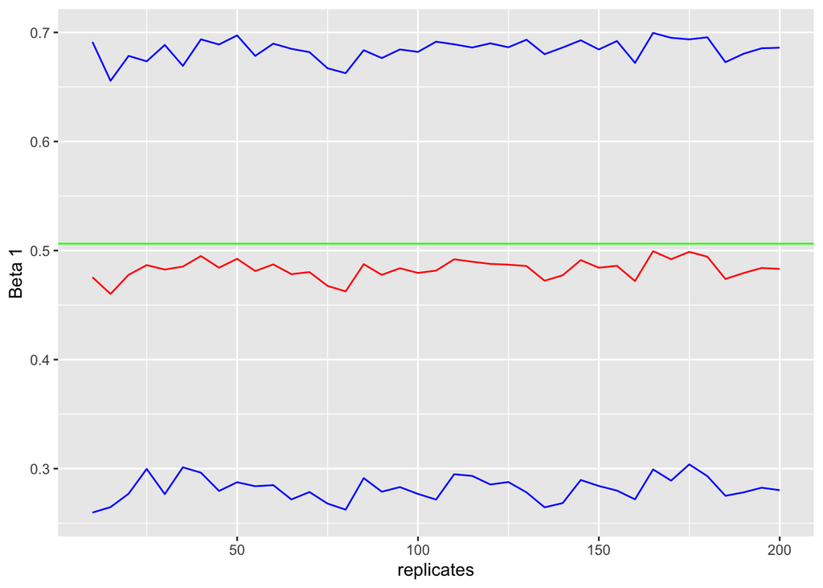

```r
f <- data.frame(replicates = numeric(),
                meanb1 = numeric(),
                meanl = numeric(),
                meanu = numeric())

for (i in seq(10, 200, by = 5)) {
  r <- boot_lm(d,"log(MeanGroupSize) ~ log(Body_mass_female_mean)", reps = i)
  f <- rbind(f, data.frame(replicates = i,
                           meanb1 = r$meanbeta1[1],
                           meanl = r$meanbeta1low[1],
                           meanu = r$meanbeta1upp[1]))
}

ggplot(f) + geom_line(aes(x = replicates, y = meanb1), color = "red") + geom_line(aes(x = replicates, y = meanl), color = "blue") + geom_line(aes(x = replicates, y = meanu), color = "blue") + geom_hline(yintercept = coef(lm(log(MeanGroupSize) ~ log(Body_mass_female_mean), d))[2], color = "green") + ylab("Beta 1")
```

Was not sure what you meant by a line???? so i did this lol